# Evaluating the Effectiveness of the Lasso Model

Sophia Frantz

# Introduction: Challenges for prediction and a potential solution through the lasso method

The purpose of this report is to assess the effectiveness of a lasso model in predicting patients’ diabetes progression from a set of health parameters. A lasso model is a model that uses methods to either penalize coefficients with large magnitudes or encourage coefficients to be small unless there is true signal that they are not really small. Lasso models are useful when trying to fit a model with data that has many variables and not enough observations to make accurate predictions of the coefficients of each variable. This is precisely the kind of data I am working with to predict diabetes progression. The diabetes dataset has 64 predictive variables and 442 observations (1 observation = 1 patient). These variables are comprised of 4 patient attributes (age, gender, body mass index, average blood pressure), six blood serum measurements (tc, ldl, hdl, tch, ltg, glu), 45 interactions, and 9 quadratic effects. Too many variables for too little data is problematic for predictions because it may result in overfitting a model. A model that is produced by overfitting will be very good at describing the given data, but it will not be good at predicting a *new* patient’s diabetes progression.

A way to prevent overfitting is to include only the most important variables in the model. However, I do not know enough about diabetes to make an informed prediction about the important variables and I do not want to choose random variables. The solution I propose is to fit a model with all the variables but try to prevent overfitting by using a lasso method in the model. The lasso method encourages coefficients to be 0 but allows them to be greater than 0 if there is enough signal to support the value. This will hopefully allow me to identify the true health attributes that influence diabetes progression and rule out the other variables. Another advantage of the lasso model is that because it encourages most variables to be small, the variables that truly contribute to the response variable can be greater than zero but not so large as to be biologically uninterpretable. Using this kind of data for prediction without a lasso method often results in large values for many coefficients, which is not as intuitive for interpretation.

The particular lasso method in this report encourages small values by setting a prior on the coefficents. The prior for all 64 coefficients is a double exponential (Laplace) distribution defined by $\mu$ and $\sigma$. The prior encourages coefficients to be small because the distribution is centered at 0, ($\mu$ = 0). $\sigma$ is chosen from an exponential distribution with $\lambda$ (rate) = 1. Thus, the distribution for priors is set up as a scale mixture, and by estimating it in the model I am allowing the diabetes data to choose a suitable scale of variation.

To assess the effectiveness of the lasso model in predicting diabetes progression, I executed the following steps:

- Fit a model with the lasso method of double-exponential priors
- Briefly look at the estimates of the coefficients
- Evaluate the model with cross-validation
- Compare the lasso model with an ordinary least squares model (with no priors or lasso methods)

# Estimating Parameters using Bayesian Inference in Stan

I used the program Stan to infer the following parameters: coefficients of the linear predictor, the intercept of the linear predictor, the approproate scale of noise for the double exponential prior on the parameters, and the appropriate scale of noise for the response variable. I included all 64 variables in the linear predictor. The response (a measure of diabetes progression) was modeled as having been sampled from a normal distribution with a mean determined by the linear predictor and a standard deviation drawn from the normal distribution with mean 0 and SD 10. I chose to model the noise of the response as normal because the response variable measuring diabetes progression seems to follow a normal distribution. As described in the Introduction above, the prior for all 64 variables is a double exponential distribution with $\mu$ = 0 and $\sigma$ = Exp(1).

**Estimates of health variables**

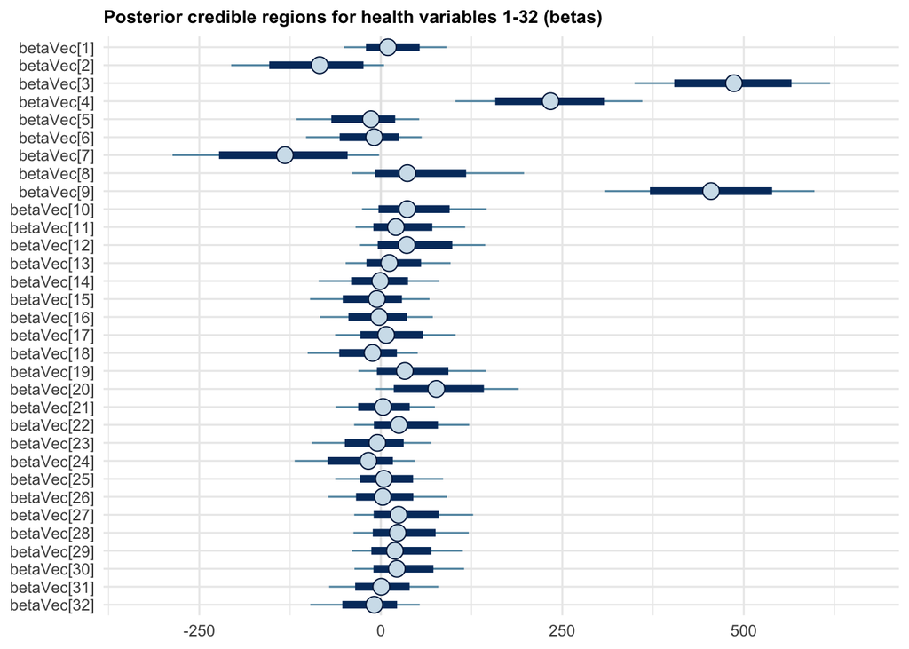

**Estimated Distribution of Noise**

The plot below shows the estimates for the intercept (b0) and both noise parameters: sig, the estimate of the noise of the response, and sigma, the estimated rate of the exponential distribution that allowed us to set up a scale mixture for the prior. The estimates are quite large, meaning there is likely a substantial amount of variation in the response variable.

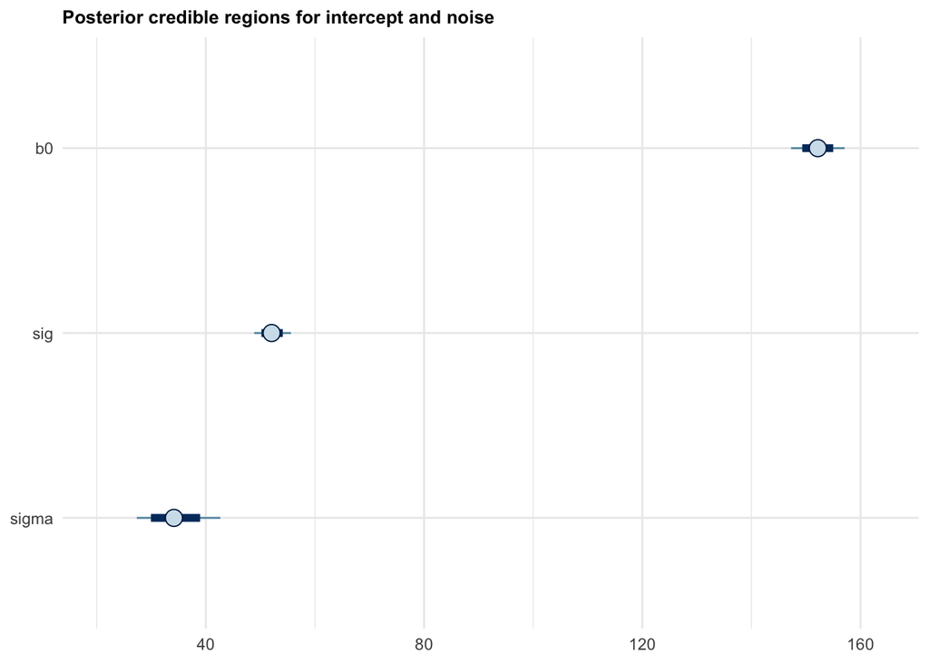

# Predictive Power of the Model

I generated estimates of the health and noise coefficients using the lasso method with this model. I do not expand much on the coefficients and what they mean for diabetes progression, because the ultimate goal of this report is to assess methods of modeling the data. I want to find the best method that will allow me to predict patients’ diabetes progression based on patient attributes. Predicting diabetes progression can help patients make treatment and management plans. With this in mind, I assessed the predictive abilities of the model described above. To do so, I split the given data into a training and testing set. I fit a model with the training data, predicted diabetes progression with the model, and measured the difference between the predictions and the actual (test) data. A good model will make predictions that are similar to the real data, so smaller differences between the two will indicate a better model. Furthermore, a good model will make predictions similar to the real data not just once but many times, with different parts of the data serving as test data. Accordingly, I repeated this process five times.

| Trial | Training_MSE | Testing_MSE |
| --- | --- | --- |
| 1 | 51 | 60 |
| 2 | 53 | 54 |
| 3 | 53 | 52 |
| 4 | 53 | 55 |
| 5 | 53 | 57 |

For each replicate of cross-validation, the MSE using the test data is not very different from the MSE of the training data. This indicates the model does not lead to overfitting.

To visualize how well the lasso model performed at predicting the diabetes response variable for “new” patients (predicting the testing data), I plotted the true values of the testing data against the predicted values. The points do not deviate much from the line of perfect correlation, which also supports the conclusion that the lasso model does not overfit the data and sufficiently predicts new values.

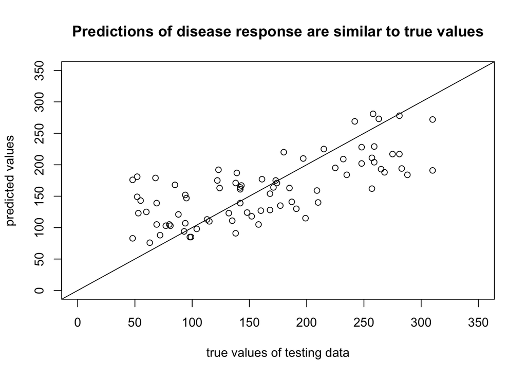

However, MSE is not an absolute measure to assess the predictive power of a model. While the plot above is good evidence the lasso model is appropriate, we do not know whether it is really performing better than a model that does not use the lasso method. Thus, I compared the predictive abilities of the lasso model to that of the same linear model but without the priors that make it a lasso model. This model uses all 64 variables to estimate coefficients. It models the noise as normal. I again used the program Stan to to infer the coefficients for all 64 variables. I will compare the two models based on 2 criteria: Their predictive abilities as measured through MSE and their interpretability. As mentioned above, large coefficients for many variables that cancel each other out are not as interpretable as coefficients of reasonable values that are only given for the truly important variables.

# Comparison to OLS

The $\hat{R}$ values of the parameters range from 1.02 - 1.25. Already this is an indication that this model does not describe the data as well as the lasso model. A coefficient plot is provided below for the coefficient estimates made with this linear model. I also show the same plot but zoomed in because the scale is so wide it is hard to tell that the estimates deviate from 0. The estimates of the coefficients in the linear model are much larger than those of the linear model with a lasso prior. This is because there are no priors on the coefficients that encourage them to be small. There is not enough data to determine a better estimate of these large coefficients, and accordingly there are very large confidence intervals for most estimates. These large estimates are more difficult to interpret and may be hard to communicate to patients and health professionals. The model also differs from the lasso model in which variables have the largest effect sizes. According to this model, the blood variables have a bigger influence in predicting diabetes progression than the other health variables sex, bmi, and average blood pressure. However, the certainty of these estimates is much lower.

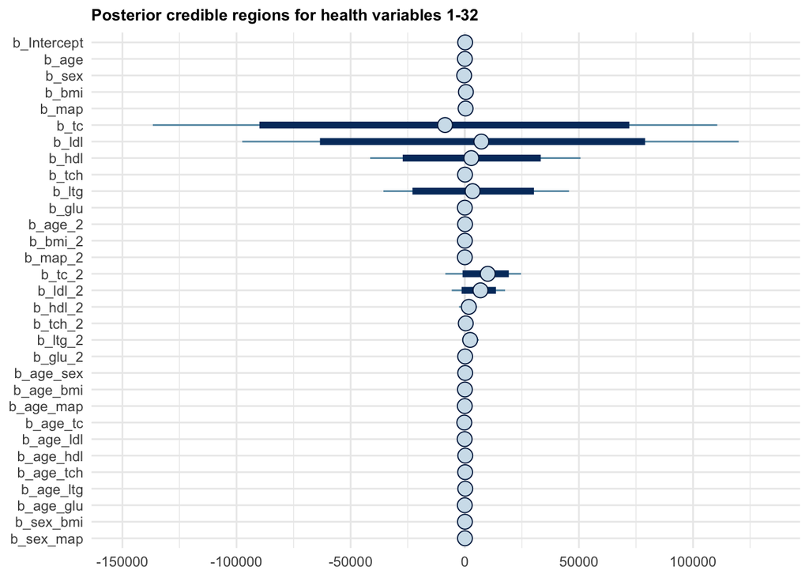

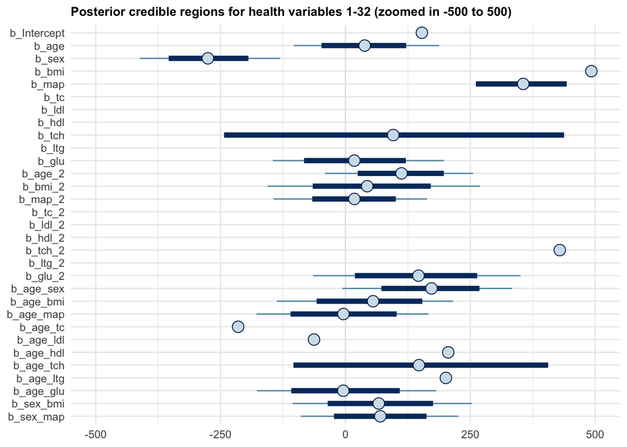

The interpretability of the ordinary linear model is inferior to the lasso model. The certainty in the estimates is lower (demonstrated by the large confidence intervals). Additionally, as shown in the table below, the predictive power of the ordinary linear model is also inferor. The difference between the testing and training MSE using the OLS model (average difference over 5 trials = 9.8) is larger than the difference using the OLS with lasso priors (average difference over 5 trials = 3.4).

| trial | training_MSE | testing_MSE |
| --- | --- | --- |
| 1 | 59 | 69 |
| 2 | 48 | 61 |
| 3 | 51 | 54 |
| 4 | 50 | 63 |
| 5 | 59 | 69 |

The inferior predictive power of the OLS model can be visualized by plotting the predictions from one trial of testing values against the true values. The deviations from the line depicting perfect prediction show that this model is less accurate in its predictions than the model that uses the lasso method.

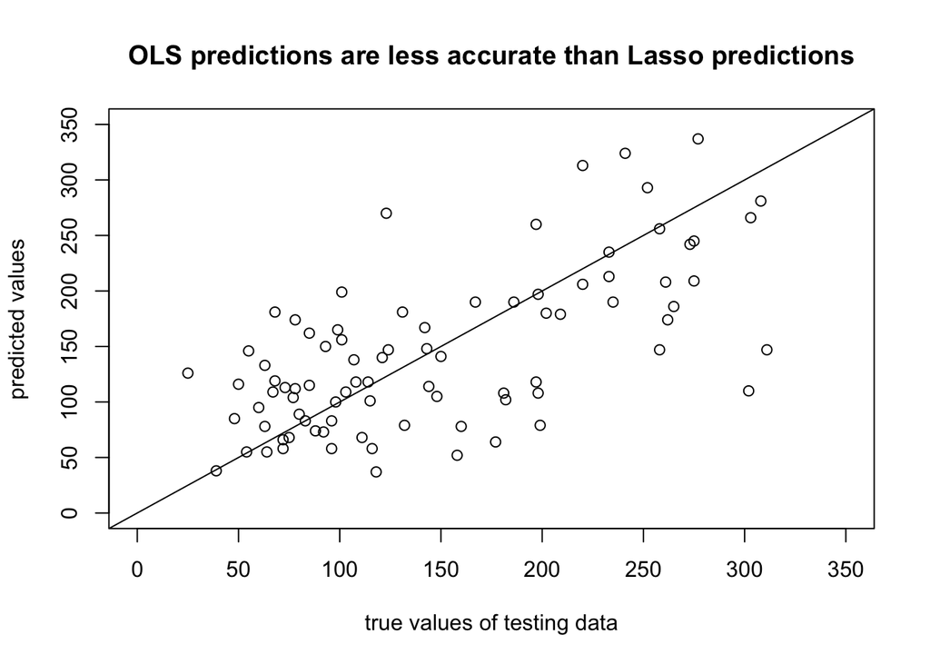

# Conclusions: Effectiveness of a sparsifying prior and future steps